# Lab 08 Activity

Author

Published

Invalid Date

### Activity Objectives:

- ANOVA

### Instructions:

- Fill in the code chunks
- Render the Quarto document and submit both the `.qmd` and `.html` file on Canvas

## Activity

### If you’d like to load packages with `library()`, please do so in this block.

```r
library(tidyverse)
```

### Download the `cake_data.csv` dataset from the GitHub. I accessed this data from [here](https://www.sumsar.net/blog/source-of-the-cake-dataset/), which also has some information on the history of the dataset. Relocate it to your folder for this class and import it into R. Please display the first few rows. Additionally, please use two other functions to get a sense of the data. This data contains the breakage angle `angle` for cakes made with different `recipes`.

```r
cake <- read_csv(here::here("lab", "data", "lab_08", "cake_data.csv"))
```

### Use a few functions to get a sense of the data.

```r
glimpse(cake)
```

```
Rows: 270
Columns: 4
$ replicate   <dbl> 1, 1, 1, 1, 1, 1, 1, 1, 1, 1, 1, 1, 1, 1, 1, 1, 1, 1, 2, 2…
$ recipe      <chr> "A", "A", "A", "A", "A", "A", "B", "B", "B", "B", "B", "B"…
$ angle       <dbl> 42, 46, 47, 39, 53, 42, 39, 46, 51, 49, 55, 42, 46, 44, 45…
$ temperature <dbl> 175, 185, 195, 205, 215, 225, 175, 185, 195, 205, 215, 225…
```

## Analysis of Variance (ANOVA)

### You’d like to test to see if there are differences in the breakage angle for cakes made with these different recipes (Recipe A, B, and C) with a one-way ANOVA. What are your null and alternative hypotheses for this test?

$H_0$: $\sigma^2_B = 0$

$H_1$: $\sigma^2_B \neq 0$

### Perform this ANOVA in the frequentist framework and display the results with `summary()`.

```r
aov(angle ~ recipe, data = cake) |> summary()
```

```
             Df Sum Sq Mean Sq F value Pr(>F)
recipe        2    135   67.54   1.001  0.369
Residuals   267  18008   67.45
```

## Check assumptions. Examine normality, outliers, and heterogeneity. Provide a brief description of whether or not the assumption checks held in the final question.

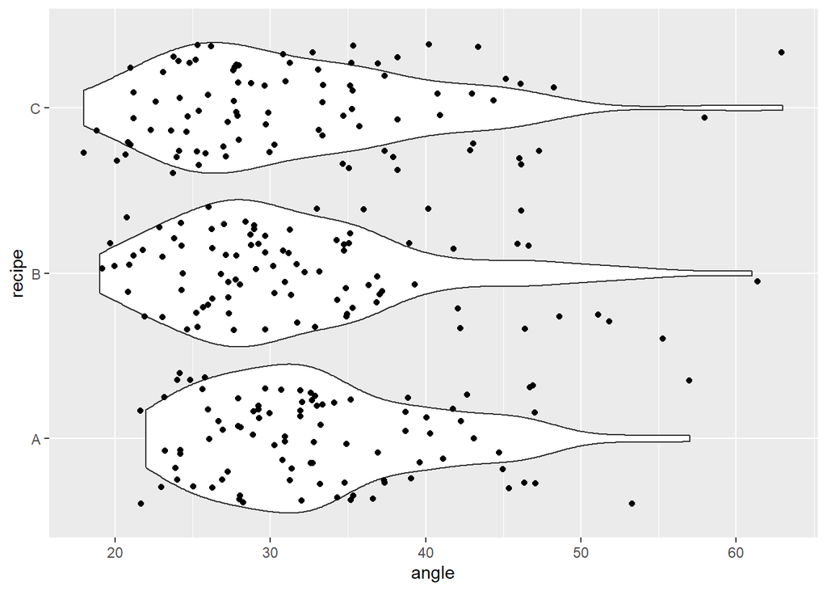

```r
cake |>
  ggplot(aes(x = angle, y = recipe)) +
  geom_violin() +
  geom_jitter()
```

### Perform this ANOVA in the Bayesian framework and display the results with `summary()`.

```r
m <- rstanarm::stan_glm(angle ~ recipe, data = cake, family = "gaussian")
summary(m)
```

```
Model Info:
 function:     stan_glm
 family:       gaussian [identity]
 formula:      angle ~ recipe
 algorithm:    sampling
 sample:       4000 (posterior sample size)
 priors:       see help('prior_summary')
 observations: 270
 predictors:   3

Estimates:
              mean   sd   10%   50%   90%
(Intercept) 33.1    0.9 32.0  33.1  34.2
recipeB     -1.5    1.2 -3.1  -1.5   0.1
recipeC     -1.5    1.2 -3.1  -1.5   0.1
sigma        8.2    0.4  7.8   8.2   8.7

Fit Diagnostics:
           mean   sd   10%   50%   90%
mean_PPD 32.1    0.7 31.3  32.1  33.0

The mean_ppd is the sample average posterior predictive distribution of the outcome variable (for details see help('summary.stanreg')).

MCMC diagnostics
              mcse Rhat n_eff
(Intercept)   0.0  1.0  3368
recipeB       0.0  1.0  3547
recipeC       0.0  1.0  3131
sigma         0.0  1.0  4261
mean_PPD      0.0  1.0  3918
log-posterior 0.0  1.0  1936

For each parameter, mcse is Monte Carlo standard error, n_eff is a crude measure of effective sample size, and Rhat is the potential scale reduction factor on split chains (at convergence Rhat=1).
```

### Check diagnostics. Provide a brief evaluation of the sampler diagnostics.

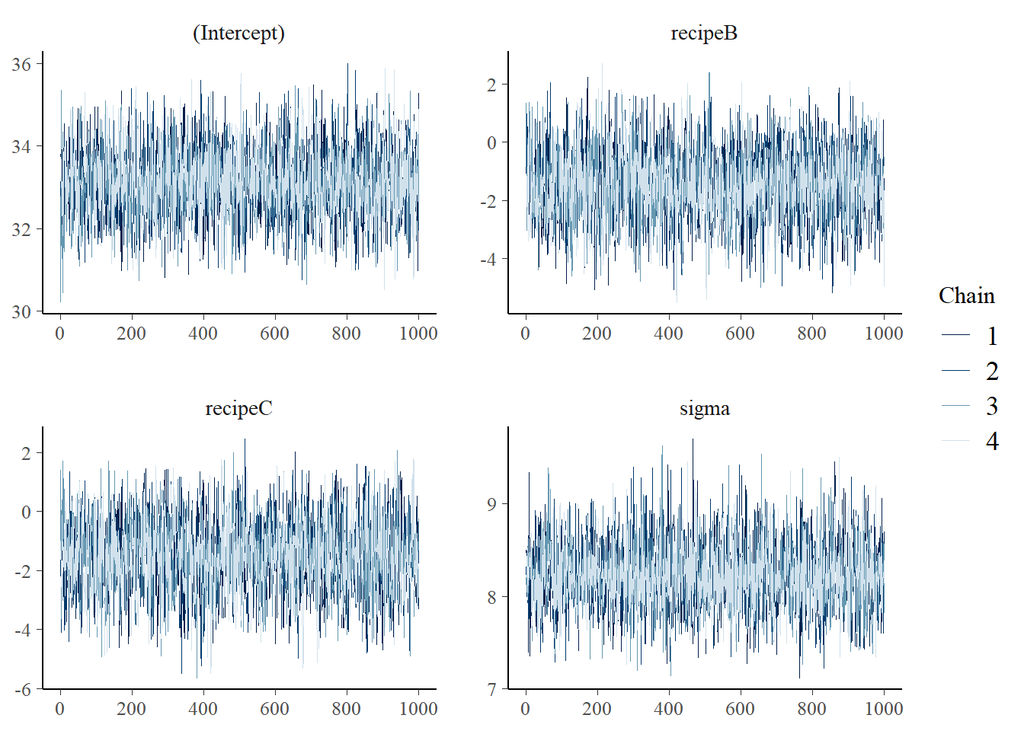

```r
bayesplot::mcmc_trace(m)
```